# Group Final Report

Author

Group 15: Dewanga Mayarata, Yasmeen R’ghioui

## 1. Data Wrangling

First, load in libraries.

```r
library(RKaggle)
library(infer)
library(knitr)
library(dplyr)
library(tidyverse)
library(ggplot2)
library(devtools)
```

Next, load the “Cancer Risk Factor” data set.

```r
Cancer_Data <- RKaggle::get_dataset("tarekmasryo/cancer-risk-factors-dataset")
print(Cancer_Data)
```

```
# A tibble: 2,000 × 21
   Patient_ID Cancer_Type   Age Gender Smoking Alcohol_Use Obesity
   <chr>      <chr>       <dbl>  <dbl>   <dbl>       <dbl>   <dbl>
 1 LU0000     Breast         68      0       7           2       8
 2 LU0001     Prostate       74      1       8           9       8
 3 LU0002     Skin           55      1       7          10       7
 4 LU0003     Colon          61      0       6           2       2
 5 LU0004     Lung           67      1      10           7       4
 6 LU0005     Lung           77      1      10           8       3
 7 LU0006     Lung           59      0      10          10       0
 8 LU0007     Prostate       74      1       8           6       2
 9 LU0008     Colon          71      1       9           0       3
10 LU0009     Skin           55      1       7           1       2
# ℹ 1,990 more rows
# ℹ 14 more variables: Family_History <dbl>, Diet_Red_Meat <dbl>,
#   Diet_Salted_Processed <dbl>, Fruit_Veg_Intake <dbl>,
#   Physical_Activity <dbl>, Air_Pollution <dbl>, Occupational_Hazards <dbl>,
#   BRCA_Mutation <dbl>, H_Pylori_Infection <dbl>, Calcium_Intake <dbl>,
#   Overall_Risk_Score <dbl>, BMI <dbl>, Physical_Activity_Level <dbl>,
#   Risk_Level <chr>
```

Data wrangling was not needed since the data set is already cleaned and organized.

## **2. Exploratory Data Analysis**

Cancer is one of the leading causes of death in the U.S.. However due to the complexity of this condition, more research is needed to understand prevention, detection, and treatment. Our group chose to explore the data set “Cancer Risk Factors” created by Tarek Masryo to determine what lifestyle, environmental, and genetic factors influence five common cancer types. Findings from this research can provide insight on how these factors influence the diagnosis of the five common cancer types and possible actions people can take to prevent diagnosis.

This dataset has 2,000 observations of individual patients and 21 variables. Of the 21 variables, 2 are character (patient ID, cancer type), 2 are numerical (age, BMI), 4 are binary (gender, family history, BRCA mutation, H. pylori infection), and 13 are ordinal (smoking, alcohol use, obesity, diet red meat, diet salted processed, fruit vegetable intake, physical activity, physical activity level, air pollution, occupational hazards, calcium intake, risk level, overall risk score).

```r
Cancer_Data %>% group_by (Cancer_Type) %>%
summarise(
  min_age = min(Age),
  max_age = max(Age),
  mean_age = mean(Age),
  min_bmi = min(BMI),
  max_bmi = max(BMI),
  mean_bmi = mean(BMI))
```

```
# A tibble: 5 × 7
  Cancer_Type min_age max_age mean_age min_bmi max_bmi mean_bmi
  <chr>         <dbl>   <dbl>    <dbl>   <dbl>   <dbl>    <dbl>
1 Breast           31      85     61.8    15.8    38.6     26.0
2 Colon            37      85     61.4    15      38.8     26.2
3 Lung             25      83     61.2    15      41.4     26.2
4 Prostate         46      90     72.5    15      38.3     26.4
5 Skin             32      86     62.2    15      36.5     26.2
```

A summary statistic was created to look the min, max, and mean for the numerical variables (age and BMI) across the 5 cancer types. The mean age for breast, colon, lung, and skin cancer are around the same. However, the mean age for prostate cancer is higher. As for BMI, the mean BMI is similar across the 5 cancer types.

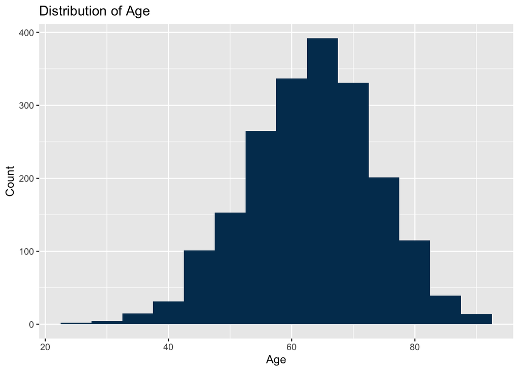

```r
ggplot(Cancer_Data, aes(x = Age)) +
  geom_histogram(binwidth = 5, fill="#003a5d") +
  labs(title = "Distribution of Age", x = "Age", y = "Count")
```

A histogram was created to look at the distribution of ages and cancer diagnosis. The histogram is unimodal and normally distributed. Most of the counts are clustered around the age of 65, suggesting that most of the diagnosis occurred around this age. It seems that there are less cancer diagnosis happens from less than ages 40 and greater than ages 85.

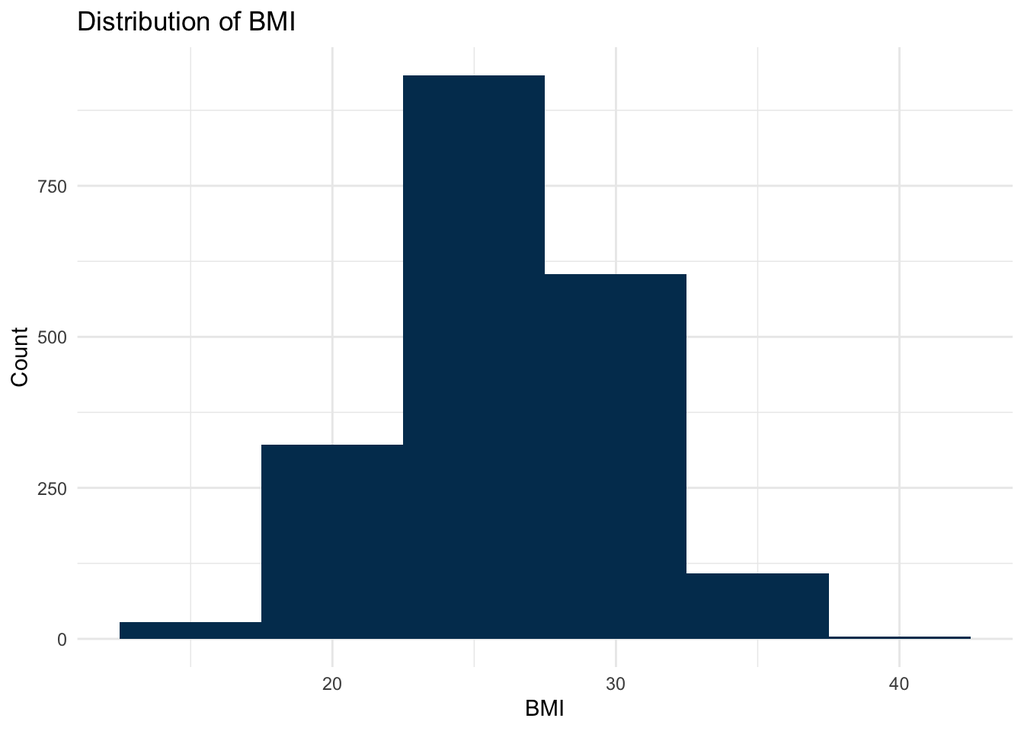

```r
ggplot(Cancer_Data, aes(x = BMI)) +
  geom_histogram(binwidth = 5, fill="#003a5d") +
  labs(title = "Distribution of BMI", x = "BMI", y = "Count") +
  theme_minimal()
```

A histogram was created to look at the distribution of BMI and cancer diagnosis. The histogram is unimodal and normally distributed. Most of the counts are clustered around the BMI of 25, suggesting most patients are around overweight.

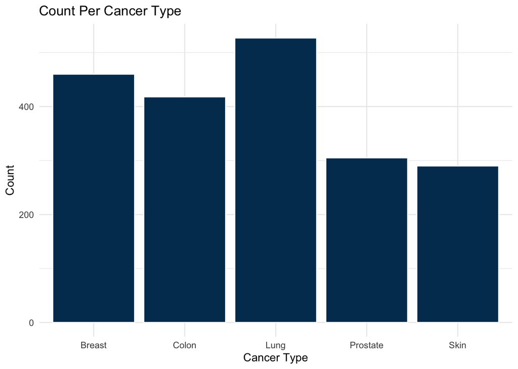

```r
ggplot(Cancer_Data, aes(x = Cancer_Type)) +
  geom_bar(color = "white", fill="#003a5d") +
  labs(title = "Count Per Cancer Type", x = "Cancer Type", y = "Count") +
  theme_minimal()
```

Based on the bar chart looking at counts per cancer type, there is a higher count of lung cancer cases, followed by breast cancer, and then colon cancer.

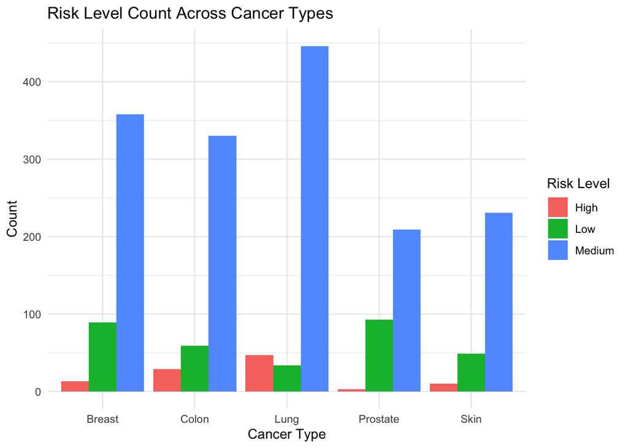

```r
ggplot(Cancer_Data, aes(x = Cancer_Type, fill = Risk_Level)) +
  geom_bar(position = "dodge") +
  labs(title = "Risk Level Count Across Cancer Types", x = "Cancer Type", y = "Count", fill = "Risk Level")+
  theme_minimal()
```

Taking a closer look at the cancer types, count was categorized into risk level. With all 5 cancer types, there is a high count of medium risk and very low count of high risk.

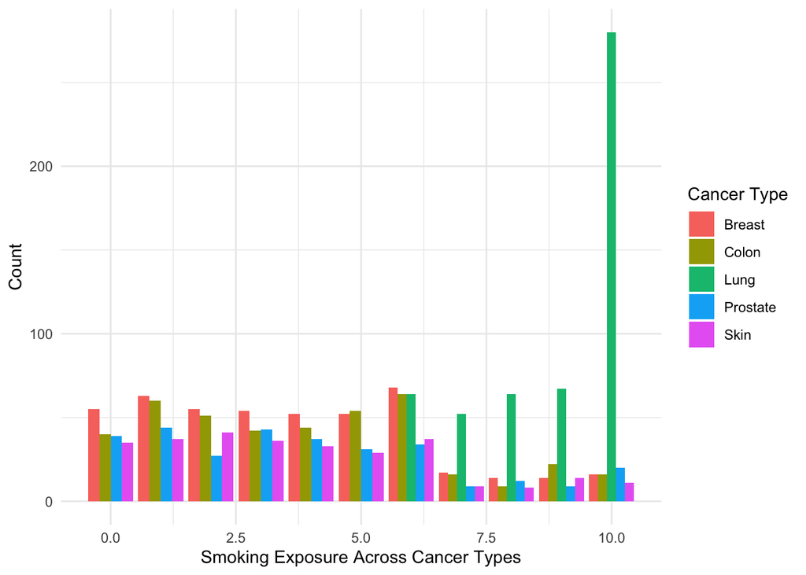

```r
ggplot(Cancer_Data, aes(x = Smoking, fill = Cancer_Type)) +
  geom_bar(position = "dodge") +
  labs(x = "Smoking Exposure Across Cancer Types", y = "Count", fill = "Cancer Type")+
  theme_minimal()
```

Smoking was an ordinal variable that was measured from 0 to 10, with the higher number indicating greater exposure or intensity. It can be seen that greater exposure to smoking was significantly observed in those with lung cancer.

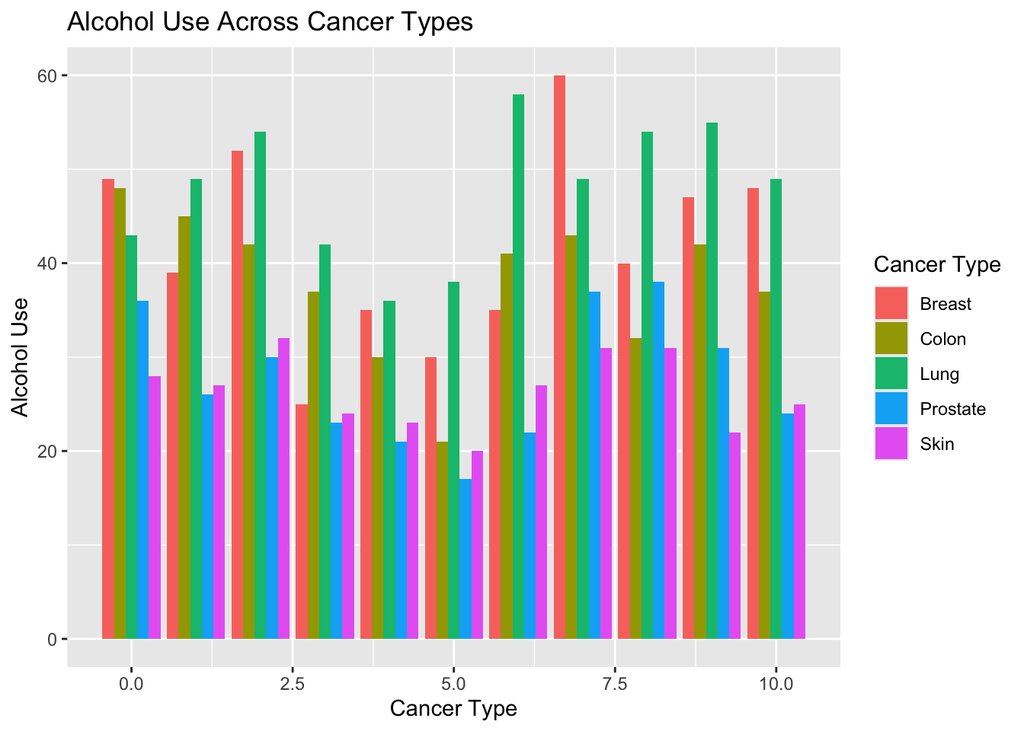

```r
ggplot(Cancer_Data, aes(x = Alcohol_Use, fill = Cancer_Type)) +
  geom_bar(position = "dodge") +
  labs(title = "Alcohol Use Across Cancer Types", x = "Cancer Type", y = "Alcohol Use", fill = "Cancer Type")
```

Alcohol use was an ordinal variable that was measured from 0 to 10, with the higher number indicating greater exposure or intensity. There is a lot of variety with alcohol use and cancer type.

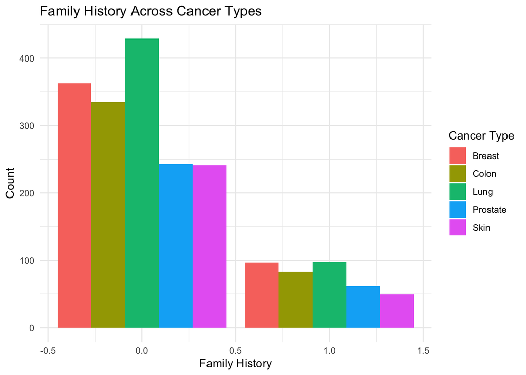

```r
ggplot(Cancer_Data, aes(x = Family_History, fill = Cancer_Type)) +
  geom_bar(position = "dodge") +
  labs(title = "Family History Across Cancer Types", x = "Family History", y = "Count", fill = "Cancer Type") +
  theme_minimal()
```

Family exposure was a binary variable. 0 means no family history and one means family history. Overall, a majority of the patients did not have a family history of cancer while less patients had family history of cancer. For those who didn’t have a family history, a large proportion of them were those who had lung cancer, followed by breast cancer.

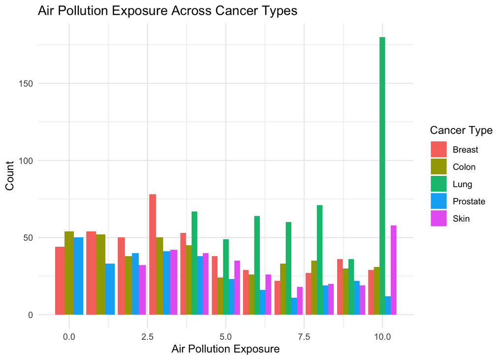

```r
ggplot(Cancer_Data, aes(x = Air_Pollution, fill = Cancer_Type)) +
  geom_bar(position = "dodge") +
  labs(title = "Air Pollution Exposure Across Cancer Types", x = "Air Pollution Exposure", y = "Count", fill = "Cancer Type")+
  theme_minimal()
```

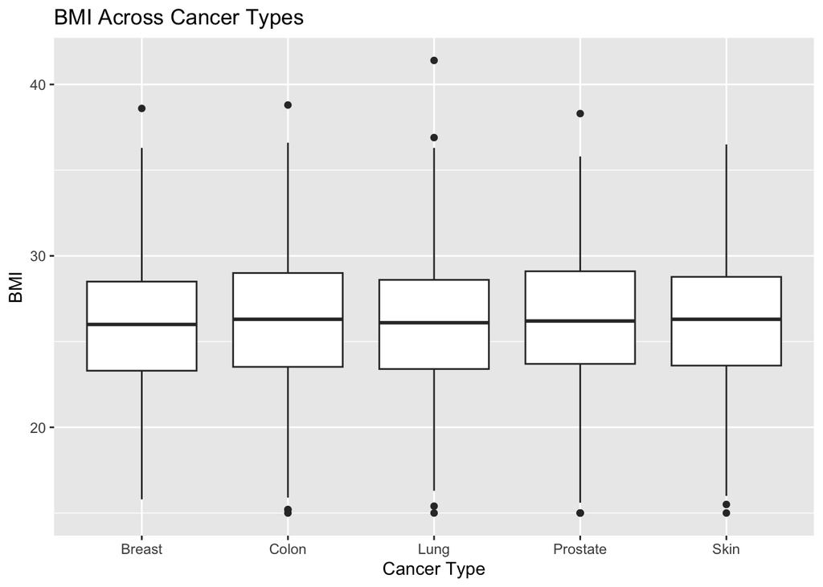

```r
ggplot(Cancer_Data, aes(x = Cancer_Type, y = BMI)) +
  geom_boxplot() +
  labs(title = "BMI Across Cancer Types", x = "Cancer Type", y = "BMI")
```

A boxplot was created to look at BMI across Cancer Type. It looks that all cancer type have a similar distribution for BMI with a few outliers. There are less outliers for Breast Caner and more outliers for lung cancer.

## 3. Hypothesis Testing: Testing a Null Statistic

For the hypothesis testing, I chose to focus on a type of cancer that I believed would be easier to categorize with the variable age. The cancer chosen was Lung cancer. According to the American Cancer Society, apart from being the second most common cancer among both men and women, the average age of a lung cancer diagnosis is 70 years old, which is why I assigned the age variable to be 70.

```r
Cancer_Data <- RKaggle::get_dataset("tarekmasryo/cancer-risk-factors-dataset")
population_age <- 70
```

For the categories I chose to take from, the options I believed would relate best for Lung cancer were Age, air pollution, and overall risk score among other things.

```r
Lung_Cancer <- Cancer_Data %>%
  filter(Cancer_Type == "Lung") %>%
  select(Age,Patient_ID, Gender, Smoking, Air_Pollution, BMI, Overall_Risk_Score)
```

```r
sample_size <- nrow (Lung_Cancer)
sample_mean <- mean (Lung_Cancer$Age)
sample_median <- median (Lung_Cancer$Age)
sample_sd <- sd (Lung_Cancer$Age)

print("Sample Statistics", quote= FALSE)
```

```
[1] Sample Statistics
```

```r
print(sample_size)
```

```
[1] 527
```

```r
print( round(sample_mean, 2))
```

```
[1] 61.22
```

```r
print(round(sample_median, 2))
```

```
[1] 62
```

```r
print(round(sample_sd, 2))
```

```
[1] 9.67
```

Next I created I bootstrap hypothesis test so I would be able to compare my mean age calculated from the sample to the mean age of the population. I set the seed at 475 to get the same number of samples every time the code is run. I picked 10,000 bootstrap samples so my p-value would be as accurate as possible and then I tested the null hypothesis by calculating the mean in comparison to the null distribution.

```r
set.seed(475)
n_bootstraps <- 10000
null_distribution <- Lung_Cancer %>%
  specify(response = Age) %>%
  hypothesize (null = "point", mu = population_age) %>%
  generate(reps = n_bootstraps, type = "bootstrap") %>%
  calculate(stat= "mean")

p_val <- null_distribution %>%
  get_p_value(obs_stat = sample_mean, direction = "two-sided")
bootstrap_se <- sd(null_distribution$stat)
score <- (sample_mean - population_age) / bootstrap_se

print("Test Results", quote= FALSE)
```

```
[1] Test Results
```

```r
print (round(sample_mean, 2))
```

```
[1] 61.22
```

```r
print(population_age)
```

```
[1] 70
```

```r
print(round(p_val$p_value,4))
```

```
[1] 0
```

```r
if (p_val$p_value < 0.05) {
  print( "Reject the null hypothesis")
} else {
  print("Fail to reject", quote = FALSE)
}
```

```
[1] "Reject the null hypothesis"
```

Lastly I graphed my bootstrap values and the sample/population ages as a visual for why the data is significant. The mean age for the lung cancer data is much lower than the predicted average age of 70.

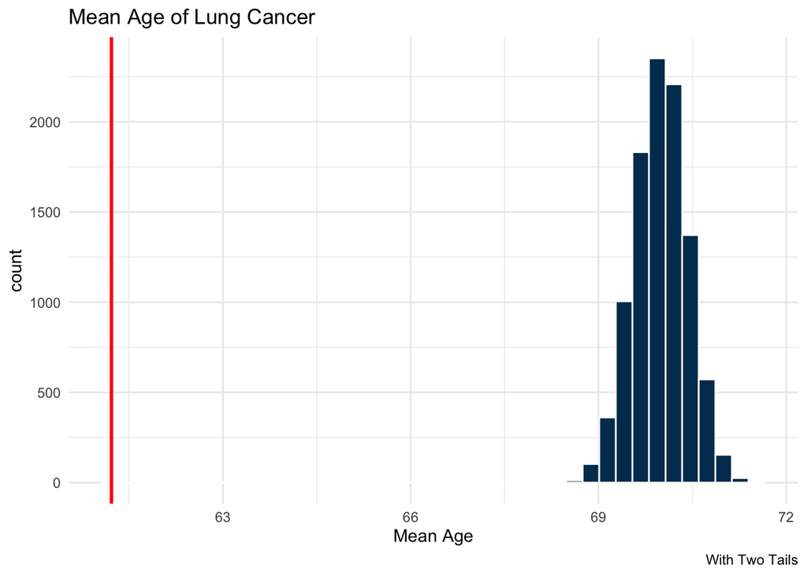

```r
ggplot (null_distribution, aes(x= stat)) +
  geom_histogram(fill = "#003A5D", color = "white", bins = 40) +
  geom_vline(xintercept = sample_mean, color = "red", linewidth = 1)+
  labs(
    title = "Mean Age of Lung Cancer" ,
    x = "Mean Age",
    caption = "With Two Tails"
  ) +
  theme_minimal()
```

## 4. Hypothesis Testing: Permutation Test

For the hypothesis testing, we looked for significant risk factors for colon cancer. Two diets were chosen, one red-meat and one high in salt and other processed foods. For the permutation test, it started off by loading in the data and then creating a High vs Low red-meat diet grouping based on the median value of Diet_Red_Meat. Then, we created a Colon Cancer (1/0) indicator and calculated the observed difference in colon cancer rates between the two diet groups of high and low. Next, we generated a null distribution by permuting the diet labels 5,000 times and computed a p-value to test whether the observed difference could be due to chance. Finally, we generated 5,000 bootstrap samples, calculated the bootstrap difference in proportions, and created a 95% bootstrap confidence interval and visualization of the bootstrap distribution.

```r
# Pick one treatment effect: explanatory: diet_red_meat(yes/no), response: colon cancer(1/0).

# Find the median of diet_red_meat
cutoff <- median(Cancer_Data$Diet_Red_Meat, na.rm = TRUE)

# Step 2: Create a new empty group column
Cancer_Data$Red_Meat_Group <- NA

# High red meat diet (>= median)
Cancer_Data$Red_Meat_Group[Cancer_Data$Diet_Red_Meat >= cutoff] <- "High"

# Low red meat in diet (< median)
Cancer_Data$Red_Meat_Group[Cancer_Data$Diet_Red_Meat < cutoff] <- "Low"

# Make sure it's treated as a categorical variable
Cancer_Data$Red_Meat_Group <- factor(Cancer_Data$Red_Meat_Group)

# Make sure cancer is numeric
Cancer_Data$ColonCancer <- ifelse(Cancer_Data$Cancer_Type == "Colon", 1, 0)
Cancer_Data$ColonCancer <- as.numeric(Cancer_Data$ColonCancer)

names(Cancer_Data)
```

```
 [1] "Patient_ID"              "Cancer_Type"
 [3] "Age"                     "Gender"
 [5] "Smoking"                 "Alcohol_Use"
 [7] "Obesity"                 "Family_History"
 [9] "Diet_Red_Meat"           "Diet_Salted_Processed"
[11] "Fruit_Veg_Intake"        "Physical_Activity"
[13] "Air_Pollution"           "Occupational_Hazards"
[15] "BRCA_Mutation"           "H_Pylori_Infection"
[17] "Calcium_Intake"          "Overall_Risk_Score"
[19] "BMI"                     "Physical_Activity_Level"
[21] "Risk_Level"              "Red_Meat_Group"
[23] "ColonCancer"
```

```r
table(Cancer_Data$Red_Meat_Group)
```

```
High  Low
1140  860
```

```r
# Compute the observed statistic

observed_stat <- Cancer_Data %>%
  group_by(Red_Meat_Group) %>%
  summarize(p = mean(ColonCancer)) %>%
  reframe(
    diff = p[Red_Meat_Group=="High"] -
      p[Red_Meat_Group=="Low"]
  ) %>%
  pull(diff)

observed_stat
```

```
[1] 0.3666667
```

```r
# Create a null distribution

set.seed(1)

perm_diffs <- replicate(5000, {
  shuffled <- sample(Cancer_Data$Red_Meat_Group)

  Cancer_Data %>%
    mutate(Diet_Red_Meat_perm = shuffled) %>%
    group_by(Diet_Red_Meat_perm) %>%
    summarize(p = mean(ColonCancer)) %>%
    summarize(diff = p[Diet_Red_Meat_perm=="High"] -
                p[Diet_Red_Meat_perm=="Low"]) %>%
    pull(diff)
})

summary(perm_diffs)
```

```
      Min.    1st Qu.     Median       Mean    3rd Qu.       Max.
-0.0698898 -0.0127703 -0.0005304  0.0001648  0.0117095  0.0667891
```

```r
table(is.na(perm_diffs))
```

```
FALSE
 5000
```

```r
head(perm_diffs)
```

```
[1] -0.01073031 -0.02909017  0.01986944 -0.03113015  0.01578947  0.01986944
```

```r
# Report the p-value and include a plot of the null distribution

p_value <- mean(abs(perm_diffs) >= abs(observed_stat))
p_value
```

```
[1] 0
```

```r
hist(
  perm_diffs,
  main = "Null Distribution (Permutation Test)",
  xlab = "Difference in Colon Cancer Rate (High - Low Red Meat)",
  breaks = 30
)+
  theme_minimal()
```

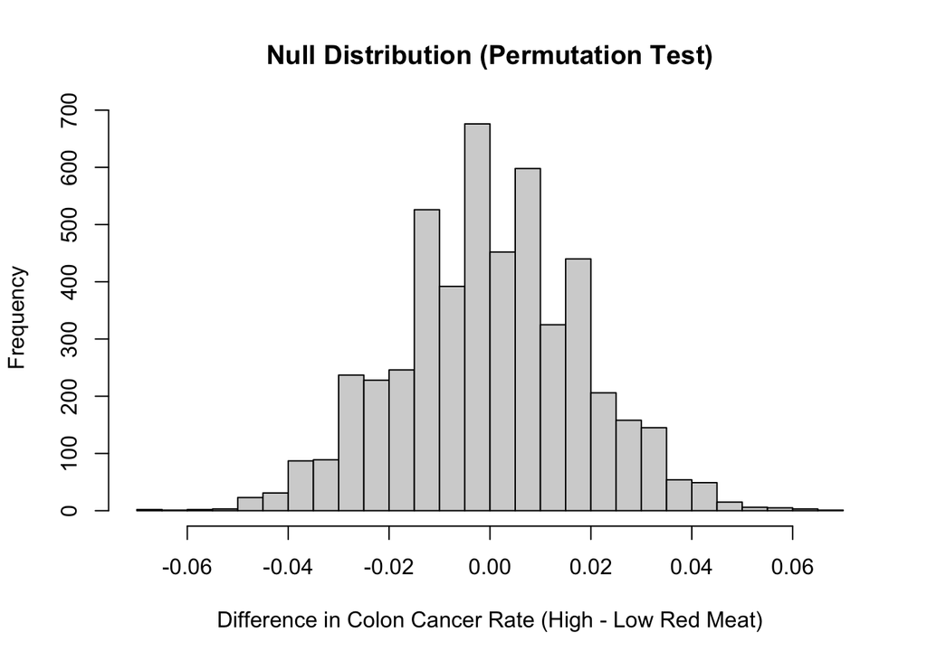

```r
abline(v = observed_stat, fill = "#003a5d", lwd = 2)
```

```r
# Add a bootstrap 95% CI
boot_obj <- Cancer_Data %>%
  specify(response = ColonCancer, explanatory = Red_Meat_Group) %>%
  generate(reps = 5000, type = "bootstrap") %>%
  calculate(stat = "diff in means", order = c("High", "Low"))

# Get 95% CI
ci <- boot_obj |> get_ci(level = 0.95)
ci
```

```
# A tibble: 1 × 2
  lower_ci upper_ci
     <dbl>    <dbl>
1    0.339    0.395
```

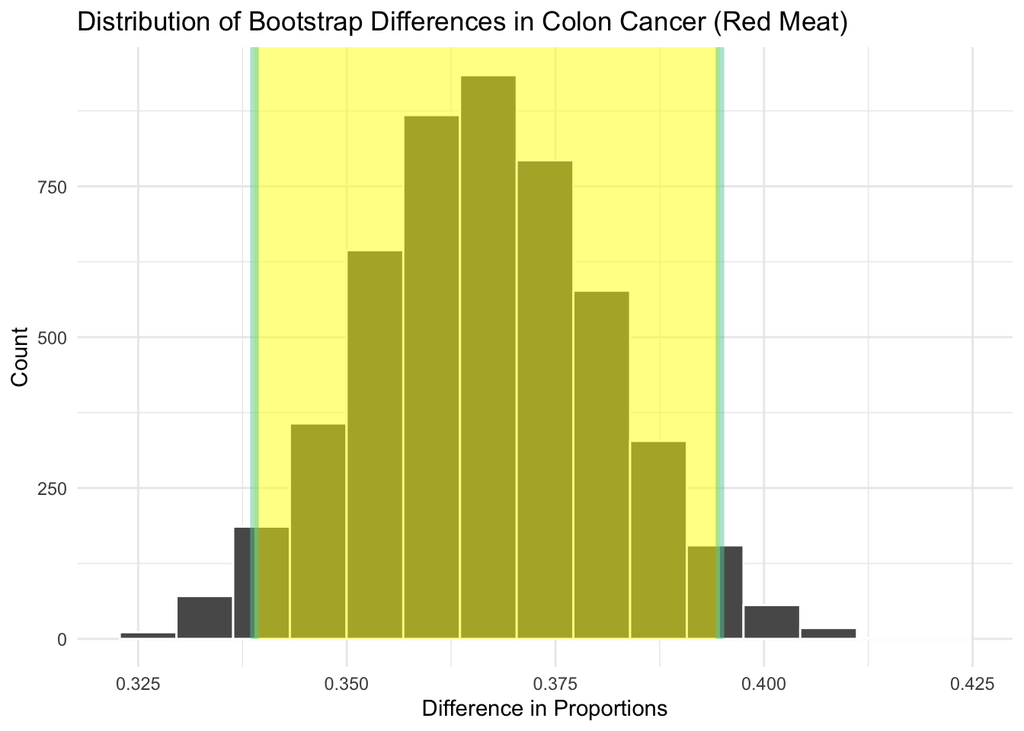

```r
boot_obj |>
  visualize(fill ="#003a5d", color = "white") +
  shade_ci(endpoints = ci, fill = "yellow", alpha = 0.5) +
  labs(
    title = "Distribution of Bootstrap Differences in Colon Cancer (Red Meat)",
    x = "Difference in Proportions",
    y = "Count"
  ) +
  theme_minimal()
```

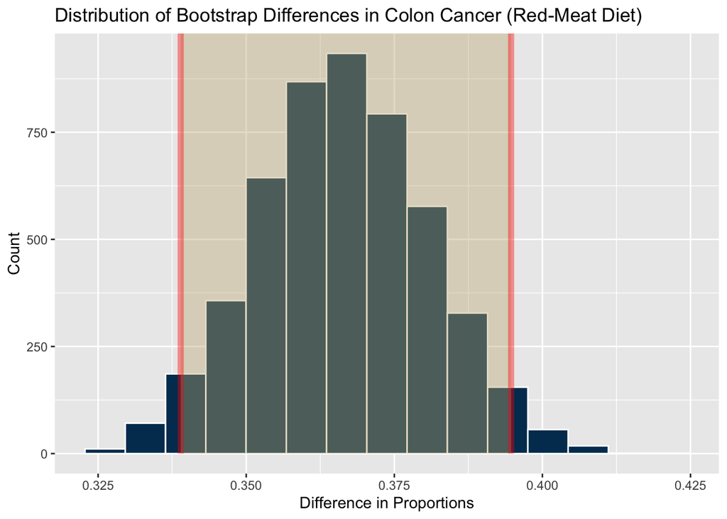

```r
# Modify the bar color:
color_graph <- boot_obj |>
  visualize() +
  shade_ci(ci, color = "red", fill = "#c6b381", alpha = 0.4)

color_graph$layers[[1]]$aes_params$fill <- "#003a5d"
color_graph$layers[[1]]$aes_params$color <- "black"

color_graph <- color_graph +
  labs(
    title = "Distribution of Bootstrap Differences in Colon Cancer (Red-Meat Diet)",
    x = "Difference in Proportions",
    y = "Count"
  )
color_graph
```

With these results, the extremely small p-value and a 95% bootstrap CI of [0.339, 0.395]—which does not include 0—provide strong evidence of a real relationship between higher red-meat consumption and increased colon cancer risk. Next, we repeated everything with the Diet_Salted_Processed and found that the p-value indicated statistical significance, and the 95% bootstrap CI of [0.119, 0.188]—which does not include 0—provides strong evidence of a real relationship between higher salted/processed food consumption and increased colon cancer risk.

```r
# Pick one treatment effect: explanatory: Diet_Salted_Processed(yes/no), response: colon cancer(1/0).

# Find the median of diet_salted_processed
cutoff_2 <- median(Cancer_Data$Diet_Salted_Processed, na.rm = TRUE)

# Step 2: Create a new empty group column
Cancer_Data$Salted_Group <- NA

# High salt in diet (>= median)
Cancer_Data$Salted_Group[Cancer_Data$Diet_Salted_Processed >= cutoff_2] <- "High"

# Low salt in diet (< median)
Cancer_Data$Salted_Group[Cancer_Data$Diet_Salted_Processed < cutoff_2] <- "Low"

# Make sure it's treated as a categorical variable
Cancer_Data$Salted_Group <- factor(Cancer_Data$Salted_Group)

# Make sure cancer is numeric
Cancer_Data$ColonCancer <- ifelse(Cancer_Data$Cancer_Type == "Colon", 1, 0)
Cancer_Data$ColonCancer <- as.numeric(Cancer_Data$ColonCancer)

names(Cancer_Data)
```

```
 [1] "Patient_ID"              "Cancer_Type"
 [3] "Age"                     "Gender"
 [5] "Smoking"                 "Alcohol_Use"
 [7] "Obesity"                 "Family_History"
 [9] "Diet_Red_Meat"           "Diet_Salted_Processed"
[11] "Fruit_Veg_Intake"        "Physical_Activity"
[13] "Air_Pollution"           "Occupational_Hazards"
[15] "BRCA_Mutation"           "H_Pylori_Infection"
[17] "Calcium_Intake"          "Overall_Risk_Score"
[19] "BMI"                     "Physical_Activity_Level"
[21] "Risk_Level"              "Red_Meat_Group"
[23] "ColonCancer"             "Salted_Group"
```

```r
table(Cancer_Data$Salted_Group)
```

```
High  Low
1147  853
```

```r
# Compute the observed statistic

observed_stat <- Cancer_Data %>%
  group_by(Salted_Group) %>%
  summarize(p = mean(ColonCancer)) %>%
  reframe(
    diff = p[Salted_Group=="High"] -
      p[Salted_Group=="Low"]
  ) %>%
  pull(diff)

observed_stat
```

```
[1] 0.1538792
```

```r
# Create a null distribution
set.seed(1)

perm_diffs <- replicate(5000, {
  shuffled <- sample(Cancer_Data$Salted_Group)

  Cancer_Data %>%
    mutate(Diet_Salted_Processed_perm = shuffled) %>%
    group_by(Diet_Salted_Processed_perm) %>%
    summarize(p = mean(ColonCancer)) %>%
    summarize(diff = p[Diet_Salted_Processed_perm=="High"] -
                p[Diet_Salted_Processed_perm=="Low"]) %>%
    pull(diff)
})

summary(perm_diffs)
```

```
      Min.    1st Qu.     Median       Mean    3rd Qu.       Max.
-0.0709798 -0.0116988  0.0005662 -0.0001325  0.0128313  0.0700681
```

```r
table(is.na(perm_diffs))
```

```
FALSE
 5000
```

```r
head(perm_diffs)
```

```
[1] -0.019875489  0.021007961  0.018963789 -0.011698799 -0.007610454
[6]  0.006698753
```

```r
# Report the p-value and include a plot of the null distribution

p_value <- mean(abs(perm_diffs) >= abs(observed_stat))
p_value
```

```
[1] 0
```

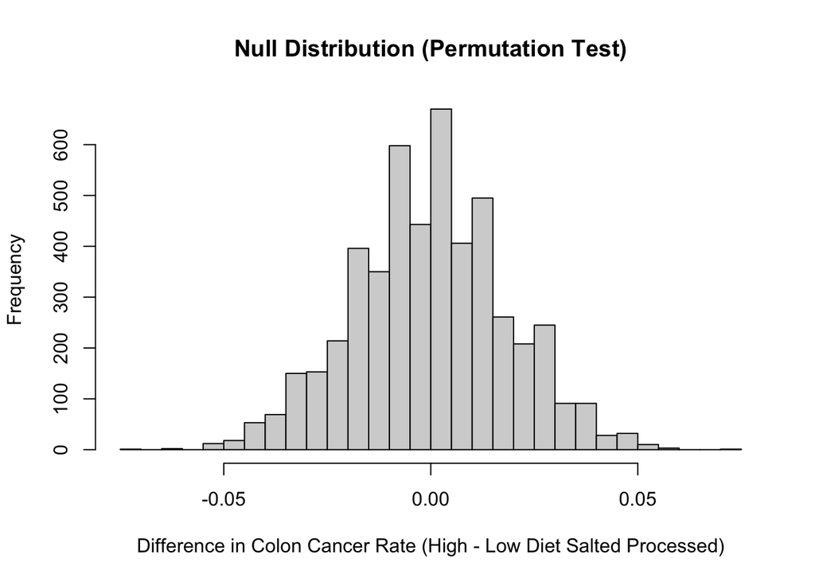

```r
hist(
  perm_diffs,
  main = "Null Distribution (Permutation Test)",
  xlab = "Difference in Colon Cancer Rate (High - Low Diet Salted Processed)",
  breaks = 30
)
abline(v = observed_stat, col = "red", lwd = 2)
```

```r
# Add a bootstrap 95% CI
boot_obj <- Cancer_Data %>%
  specify(response = ColonCancer, explanatory = Salted_Group) %>%
  generate(reps = 5000, type = "bootstrap") %>%
  calculate(stat = "diff in means", order = c("High", "Low"))


# Get 95% CI
ci <- boot_obj |> get_ci(level = 0.95)
ci
```

```
# A tibble: 1 × 2
  lower_ci upper_ci
     <dbl>    <dbl>
1    0.119    0.188
```

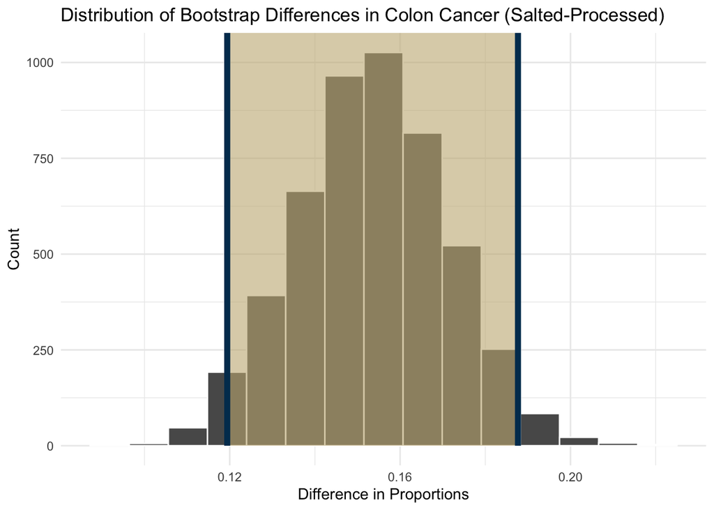

```r
boot_obj |>
  visualize() +
  shade_ci(ci, color = "#003a5d", fill = "#C6B381") +
  labs(
    title = "Distribution of Bootstrap Differences in Colon Cancer (Salted-Processed)",
    x = "Difference in Proportions",
    y = "Count"
  ) +
  theme_minimal()
```

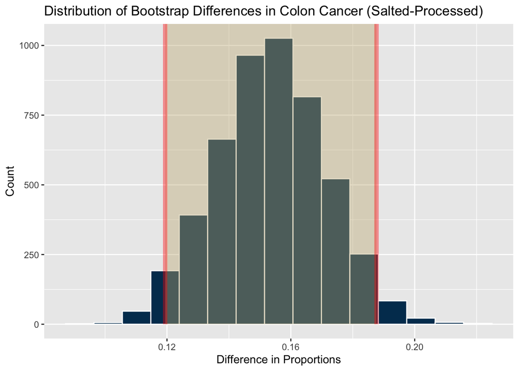

```r
# Modify the bar color:
color_graph_2 <- boot_obj |>
  visualize() +
  shade_ci(ci, color = "red", fill = "#c6b381", alpha = 0.4)

color_graph_2$layers[[1]]$aes_params$fill <- "#003a5d"
color_graph_2$layers[[1]]$aes_params$color <- "black"

color_graph_2 <- color_graph_2 +
  labs(
    title = "Distribution of Bootstrap Differences in Colon Cancer (Salted-Processed)",
    x = "Difference in Proportions",
    y = "Count"
  )
color_graph_2
```

## 5. Modeling Relationships (Correlation and Regression)

```r
Cancer_Data$ProstateCancer <- ifelse(Cancer_Data$Cancer_Type == "Prostate", 1, 0)
Cancer_Data$ProstateCancer <- as.numeric(Cancer_Data$ProstateCancer)
str(Cancer_Data$Gender)
```

```
 num [1:2000] 0 1 1 0 1 1 0 1 1 1 ...
```

```r
summary(Cancer_Data$Gender)
```

```
   Min. 1st Qu.  Median    Mean 3rd Qu.    Max.
  0.000   0.000   0.000   0.489   1.000   1.000
```

```r
model <- lm(ProstateCancer ~ Age, data = Cancer_Data)
summary(model)
```

```
Call:
lm(formula = ProstateCancer ~ Age, data = Cancer_Data)

Residuals:
     Min       1Q   Median       3Q      Max
-0.44489 -0.20072 -0.11076  0.02097  1.06916

Coefficients:
              Estimate Std. Error t value Pr(>|t|)
(Intercept) -0.6603249  0.0457153  -14.44   <2e-16 ***
Age          0.0128514  0.0007131   18.02   <2e-16 ***
---
Signif. codes:  0 '***' 0.001 '**' 0.01 '*' 0.05 '.' 0.1 ' ' 1

Residual standard error: 0.3336 on 1998 degrees of freedom
Multiple R-squared:  0.1398,    Adjusted R-squared:  0.1394
F-statistic: 324.8 on 1 and 1998 DF,  p-value: < 2.2e-16
```

```r
coef(model)
```

```
(Intercept)         Age
-0.66032485  0.01285139
```

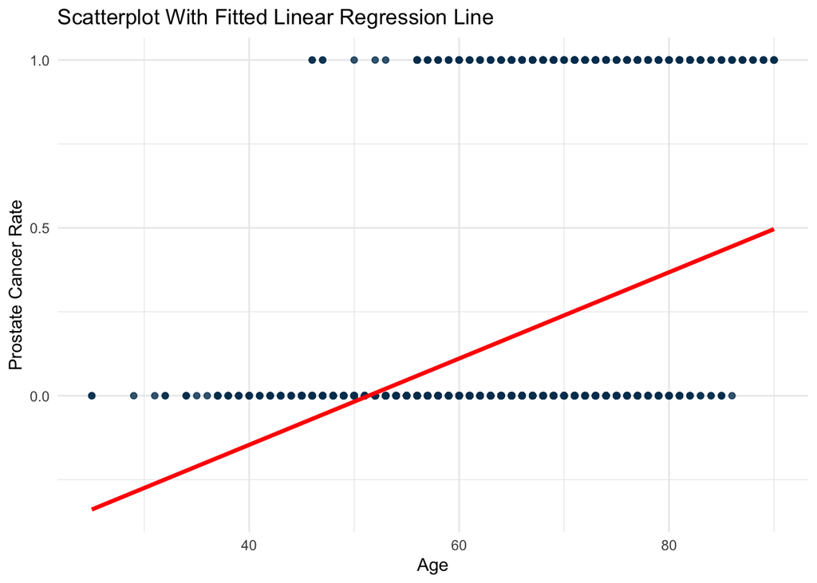

```r
ggplot(Cancer_Data, aes(x = Age, y = ProstateCancer)) +
  geom_point(alpha = 0.8, color = "#003a5d") +
  geom_smooth(method = "lm", se = FALSE,
              color = "red", linewidth = 1.2) +

  labs(
    x = "Age",
    y = "Prostate Cancer Rate",
    title = "Scatterplot With Fitted Linear Regression Line"
  ) +
  theme_minimal()
```

Next, we used bootstrap resampling to estimate the sampling distribution of the slope for ProstateCancer predicted by Age. We started by creating a seperate dataset that only had cancer data for males because Prostate Cancer onlu affects males. By generating 5,000 bootstrap samples and calculating the slope for each, we assessed the variability of the estimated relationship. A 95% bootstrap confidence interval was then computed, ranging from 0.0178 to 0.0228, indicating that the slope is consistently positive across resamples. The scatterplot shows that prostate cancer rate tends to increase slightly with age. The fitted regression line indicates a positive relationship. The confidence interval for the slope is very narrow and entirely above zero, supporting that the increase in age is significantly associated with a higher cancer rate.

```r
cancer_males <- Cancer_Data %>%
  filter(Gender == 1)

cancer_males$ProstateCancer <- ifelse(cancer_males$Cancer_Type == "Prostate", 1, 0)
cancer_males$ProstateCancer <- as.numeric(cancer_males$ProstateCancer)


model <- lm(ProstateCancer ~ Age, data = cancer_males)
summary(model)
```

```
Call:
lm(formula = ProstateCancer ~ Age, data = cancer_males)

Residuals:
    Min      1Q  Median      3Q     Max
-0.7125 -0.3264 -0.1639  0.3891  1.1003

Coefficients:
             Estimate Std. Error t value Pr(>|t|)
(Intercept) -1.035111   0.092181  -11.23   <2e-16 ***
Age          0.020321   0.001376   14.77   <2e-16 ***
---
Signif. codes:  0 '***' 0.001 '**' 0.01 '*' 0.05 '.' 0.1 ' ' 1

Residual standard error: 0.4192 on 976 degrees of freedom
Multiple R-squared:  0.1827,    Adjusted R-squared:  0.1818
F-statistic: 218.1 on 1 and 976 DF,  p-value: < 2.2e-16
```

```r
coef(model)
```

```
(Intercept)         Age
-1.03511090  0.02032146
```

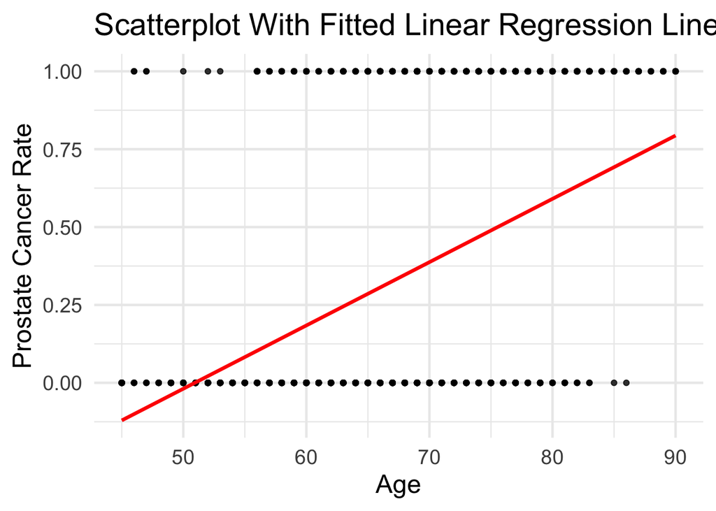

```r
ggplot(cancer_males, aes(x = Age, y = ProstateCancer)) +
  geom_point(alpha = 0.8) +
  geom_smooth(method = "lm", se = FALSE,
              color = "red", linewidth = 1.2) +
  labs(
    x = "Age",
    y = "Prostate Cancer Rate",
    title = "Scatterplot With Fitted Linear Regression Line"
  ) +
  theme_minimal(base_size = 18)
```

```r
set.seed(1)

boot_slope <- cancer_males %>%
  specify(ProstateCancer ~ Age) %>%
  generate(reps = 5000, type = "bootstrap") %>%
  calculate(stat = "slope")

# 95% CI
slope_ci <- boot_slope %>% get_ci(level = 0.95)
slope_ci
```

```
# A tibble: 1 × 2
  lower_ci upper_ci
     <dbl>    <dbl>
1   0.0178   0.0228
```